## Acknowledgments

This project was for the Hackathon at the end of the MIT Data Science and Machine Learning course offered by Great Learning (Sept '23 cohort). The dataset and the challenge structure were provided by this course. This hackathon served as a capstone to the intensive learning journey in the course, allowing the application of skills and techniques learned throughout.

# Problem Background and Statement

Goal: The goal of the problem is to predict whether a passenger was satisfied or not considering his/her overall experience of travelling on the Shinkansen Bullet Train.

Dataset:

The problem consists of 2 separate datasets: Travel data & Survey data. Travel data has information related to passengers and attributes related to the Shinkansen train, in which they travelled. The survey data is aggregated data of surveys indicating the post-service experience. You are expected to treat both these datasets as raw data and perform any necessary data cleaning/validation steps as required.

The data has been split into two groups and provided in the Dataset folder. The folder contains both train and test data separately.

Train_Data Test_Data

Target Variable: Overall_Experience (1 represents ‘satisfied’, and 0 represents ‘not satisfied’)

The training set can be used to build your machine-learning model. The training set has labels for the target column - Overall_Experience.

The testing set should be used to see how well your model performs on unseen data. For the test set, it is expected to predict the ‘Overall_Experience’ level for each participant.

Submission File Format: You will need to submit a CSV file with exactly 35,602 entries plus a header row. The file should have exactly two columns

## Data Dictionary:

Travel Data Dictionary:

- ID: Unique identifier for each passenger.
- Gender: Passenger's gender.
- Customer_Type: Indicates if the passenger is a loyal or disloyal customer.
- Age: Age of the passenger.
- Type_Travel: Purpose of the travel (Personal or Business).
- Travel_Class: Class of travel on the train (Business or Eco).
- Travel_Distance: Distance traveled by the passenger.
- Departure_Delay_in_Mins: Train departure delay in minutes.
- Arrival_Delay_in_Mins: Train arrival delay in minutes.

Survey Data Dictionary:

- ID: Unique identifier for each passenger (same as in Travel Data).
- Platform_Location: Passenger's convenience rating for the platform location.
- Seat_Class: Type of seat class in the train (Ordinary or Green Car).
- Overall_Experience: Passenger's overall satisfaction (1 for Satisfied, 0 for Not Satisfied).
- Seat_Comfort,
- Arrival_Time_Convenient,
- Catering,
- Onboard_Wifi_Service,
- Onboard_Entertainment,
- Online_Support,
- Ease_of_Online_Booking,
- Onboard_Service,
- Legroom,
- Baggage_Handling,
- CheckIn_Service,
- Cleanliness,
- Online_Boarding:

These fields represent passenger ratings on various aspects of their experience, ranging from 'Extremely Poor' to 'Excellent'.

# Uploading the libraries and datasets

```python
from google.colab import drive
drive.mount('/content/drive')
```

```python
# Data Handling
import pandas as pd
import numpy as np

# Visualization
import matplotlib.pyplot as plt
import seaborn as sns

# Preprocessing
from sklearn.model_selection import train_test_split
from sklearn.preprocessing import StandardScaler, OneHotEncoder, LabelEncoder
from sklearn.compose import ColumnTransformer
from sklearn.pipeline import Pipeline

# Model Algorithms
from sklearn.linear_model import LogisticRegression
from sklearn.ensemble import RandomForestClassifier, GradientBoostingClassifier

# Model Evaluation
from sklearn.metrics import accuracy_score, classification_report, confusion_matrix
```

```python
# File paths
travel_data_train_path = 'Traveldata_train.csv'
survey_data_train_path = 'Surveydata_train.csv'
travel_data_test_path = 'Traveldata_test.csv'
survey_data_test_path = 'Surveydata_test.csv'

# Load the datasets
travel_data_train = pd.read_csv(travel_data_train_path)
survey_data_train = pd.read_csv(survey_data_train_path)
travel_data_test = pd.read_csv(travel_data_test_path)
survey_data_test = pd.read_csv(survey_data_test_path)
```

# Data Exploration and Cleaning

Exploring and verifying the data structures and types are critical to understanding the data that you're working with.

```python
# Quick look at the data structures
print(travel_data_train.head())
print(survey_data_train.head())
print(travel_data_test.head())
print(survey_data_test.head())
```

```
         ID  Gender   Customer_Type   Age      Type_Travel Travel_Class  \
0  98800001  Female  Loyal Customer  52.0              NaN     Business
1  98800002    Male  Loyal Customer  48.0  Personal Travel          Eco
2  98800003  Female  Loyal Customer  43.0  Business Travel     Business
3  98800004  Female  Loyal Customer  44.0  Business Travel     Business
4  98800005  Female  Loyal Customer  50.0  Business Travel     Business

   Travel_Distance  Departure_Delay_in_Mins  Arrival_Delay_in_Mins
0              272                      0.0                    5.0
1             2200                      9.0                    0.0
2             1061                     77.0                  119.0
3              780                     13.0                   18.0
4             1981                      0.0                    0.0
         ID  Overall_Experience       Seat_Comfort Seat_Class  \
0  98800001                   0  Needs Improvement  Green Car
```

[output cut: 72 more lines]

```python
travel_data_test.head()
```

|  | ID | Gender | Customer_Type | Age | Type_Travel | Travel_Class | Travel_Distance | Departure_Delay_in_Mins | Arrival_Delay_in_Mins |
| --- | --- | --- | --- | --- | --- | --- | --- | --- | --- |
| 0 | 99900001 | Female | NaN | 36.0 | Business Travel | Business | 532 | 0.0 | 0.0 |
| 1 | 99900002 | Female | Disloyal Customer | 21.0 | Business Travel | Business | 1425 | 9.0 | 28.0 |
| 2 | 99900003 | Male | Loyal Customer | 60.0 | Business Travel | Business | 2832 | 0.0 | 0.0 |
| 3 | 99900004 | Female | Loyal Customer | 29.0 | Personal Travel | Eco | 1352 | 0.0 | 0.0 |
| 4 | 99900005 | Male | Disloyal Customer | 18.0 | Business Travel | Business | 1610 | 17.0 | 0.0 |

The data so far takes the expected shapes and structures as described in the data dictionary.

```python
# Checking the shape of the different datasets

# Print the shapes of all four datasets
print("Travel Data Train Shape:", travel_data_train.shape)
print("Survey Data Train Shape:", survey_data_train.shape)
print("Travel Data Test Shape:", travel_data_test.shape)
print("Survey Data Test Shape:", survey_data_test.shape)
```

```
Travel Data Train Shape: (94379, 9)
Survey Data Train Shape: (94379, 17)
Travel Data Test Shape: (35602, 9)
Survey Data Test Shape: (35602, 16)
```

These are the same shapes, except that the survey data test dataset is missing a column, which we would expect as it does not contain the target variable of "Satisfied with trip".

```python
# Looking for duplicates

# Identifying duplicate rows in the Travel Data Train dataset
duplicates_travel_train = travel_data_train.duplicated()
print("Number of duplicate rows in Travel Data Train:", duplicates_travel_train.sum())

# Identifying duplicate rows in the Survey Data Train dataset
duplicates_survey_train = survey_data_train.duplicated()
print("Number of duplicate rows in Survey Data Train:", duplicates_survey_train.sum())

# Identifying duplicate rows in the Travel Data Test dataset
duplicates_travel_test = travel_data_test.duplicated()
print("Number of duplicate rows in Travel Data Test:", duplicates_travel_test.sum())

# Identifying duplicate rows in the Survey Data Test dataset
duplicates_survey_test = survey_data_test.duplicated()
print("Number of duplicate rows in Survey Data Test:", duplicates_survey_test.sum())

# Dropping duplicates if need be:
# travel_data_train = travel_data_train.drop_duplicates()
# survey_data_train = survey_data_train.drop_duplicates()
# travel_data_test = travel_data_test.drop_duplicates()
# survey_data_test = survey_data_test.drop_duplicates()
```

```
Number of duplicate rows in Travel Data Train: 0
Number of duplicate rows in Survey Data Train: 0
Number of duplicate rows in Travel Data Test: 0
Number of duplicate rows in Survey Data Test: 0
```

No duplicate rows found in any of the datasets. Moving on to further exploration of the travel_data_train set.

## Exploring travel_data_train

```python
travel_data_train.head()
```

[output not shown]

```python
travel_data_train.tail()
```

|  | ID | Gender | Customer_Type | Age | Type_Travel | Travel_Class | Travel_Distance | Departure_Delay_in_Mins | Arrival_Delay_in_Mins |
| --- | --- | --- | --- | --- | --- | --- | --- | --- | --- |
| 94374 | 98894375 | Male | Loyal Customer | 32.0 | Business Travel | Business | 1357 | 83.0 | 125.0 |
| 94375 | 98894376 | Male | Loyal Customer | 44.0 | Business Travel | Business | 592 | 5.0 | 11.0 |
| 94376 | 98894377 | Male | NaN | 63.0 | Business Travel | Business | 2794 | 0.0 | 0.0 |
| 94377 | 98894378 | Male | Loyal Customer | 16.0 | Personal Travel | Eco | 2744 | 0.0 | 0.0 |
| 94378 | 98894379 | Male | Loyal Customer | 54.0 | NaN | Eco | 2107 | 28.0 | 28.0 |

This data set contains ID, Gender, Customer_Type, Age (as a float), Type_Travel (business or personal), Travel_Class (Business or Eco), Travel_Distance, Departure_Delay_in_Mins, and Arrival_Delay_in_Mins. This is all as described in the data dictionary.

```python
travel_data_train.info()
```

```
<class 'pandas.core.frame.DataFrame'>
RangeIndex: 94379 entries, 0 to 94378
Data columns (total 9 columns):
 #   Column                   Non-Null Count  Dtype
---  ------                   --------------  -----
 0   ID                       94379 non-null  int64
 1   Gender                   94302 non-null  object
 2   Customer_Type            85428 non-null  object
 3   Age                      94346 non-null  float64
 4   Type_Travel              85153 non-null  object
 5   Travel_Class             94379 non-null  object
 6   Travel_Distance          94379 non-null  int64
 7   Departure_Delay_in_Mins  94322 non-null  float64
 8   Arrival_Delay_in_Mins    94022 non-null  float64
dtypes: float64(3), int64(2), object(4)
memory usage: 6.5+ MB
```

```python
travel_data_train.describe().T
```

|  | count | mean | std | min | 25% | 50% | 75% | max |
| --- | --- | --- | --- | --- | --- | --- | --- | --- |
| ID | 94379.0 | 9.884719e+07 | 27245.014865 | 98800001.0 | 98823595.5 | 98847190.0 | 98870784.5 | 98894379.0 |
| Age | 94346.0 | 3.941965e+01 | 15.116632 | 7.0 | 27.0 | 40.0 | 51.0 | 85.0 |
| Travel_Distance | 94379.0 | 1.978888e+03 | 1027.961019 | 50.0 | 1359.0 | 1923.0 | 2538.0 | 6951.0 |
| Departure_Delay_in_Mins | 94322.0 | 1.464709e+01 | 38.138781 | 0.0 | 0.0 | 0.0 | 12.0 | 1592.0 |
| Arrival_Delay_in_Mins | 94022.0 | 1.500522e+01 | 38.439409 | 0.0 | 0.0 | 0.0 | 13.0 | 1584.0 |

```python
travel_data_train.describe(include=[object]).T
```

|  | count | unique | top | freq |
| --- | --- | --- | --- | --- |
| Gender | 94302 | 2 | Female | 47815 |
| Customer_Type | 85428 | 2 | Loyal Customer | 69823 |
| Type_Travel | 85153 | 2 | Business Travel | 58617 |
| Travel_Class | 94379 | 2 | Eco | 49342 |

```python
# Checking for bad data and non-numerical characters in the numerical columns

# Assuming travel_data_test is your DataFrame
columns_to_check = travel_data_train.select_dtypes(include=['float64', 'int64']).columns

# Regular expression for non-numerical characters
regex_pattern = '[^\d.-]'

for column in columns_to_check:
    # Find rows with non-numerical data ignoring NaN values
    non_numerical_rows = travel_data_test[column].dropna().astype(str).str.contains(regex_pattern, regex=True)

    # Get indices of these rows
    non_numerical_indices = non_numerical_rows[non_numerical_rows].index

    if not non_numerical_indices.empty:
        print(f"Column '{column}' has {len(non_numerical_indices)} rows with non-numerical data.")
        print(f"Indices of these rows: {list(non_numerical_indices)}")

    else:
        print(f"No non-numerical data found in '{column}'.")
```

```
No non-numerical data found in 'ID'.
No non-numerical data found in 'Age'.
No non-numerical data found in 'Travel_Distance'.
No non-numerical data found in 'Departure_Delay_in_Mins'.
No non-numerical data found in 'Arrival_Delay_in_Mins'.
```

Summary of Data Preparation Steps: 'ID': This is a unique identifier and will not be used in the model training process. However, it's essential to keep it in the test set for the final submission, and I want to keep it in the train set for now because I will use it to join with the survey data.

'Gender': As there are only 77 missing values out of about 94,000, I will impute the missing values with the mode (most frequent value) of this column. After handling the missing values, I will convert the datatype to 'category' and apply one-hot encoding.

'Customer_Type' and 'Type_Travel': Both columns have around 10% missing data. I will create an 'Unknown' category for the missing values to capture the potential informativeness of the missingness. Then, I will convert these to 'category' datatypes and apply one-hot encoding.

'Age': The missing values in this column will be imputed using the median age. Though the data type is float, it's not necessary to convert it to integers as the floats seem to be whole numbers, and the conversion won't significantly impact the model's performance.

'Travel_Class': I will convert this column to a 'category' datatype and apply one-hot encoding.

'Travel_Distance': No specific handling is required for this column as there are no missing values.

Before taking these steps, I will examine the travel_data_test dataset to see if these changes make sense given that data as well, then apply all transformations to both.

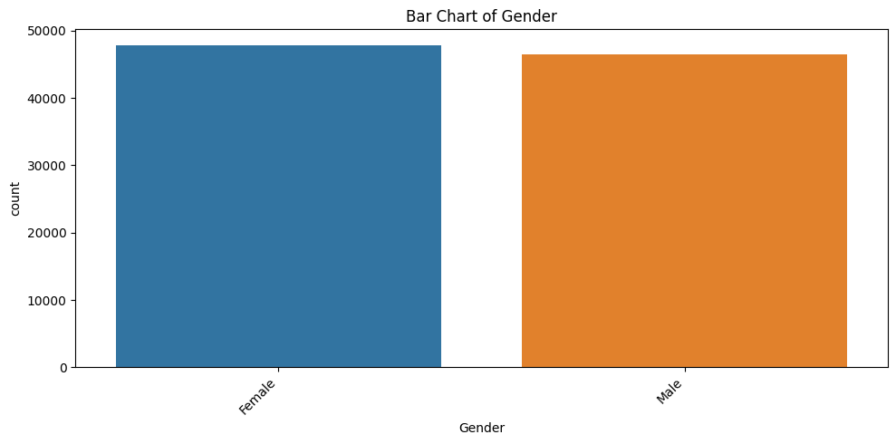

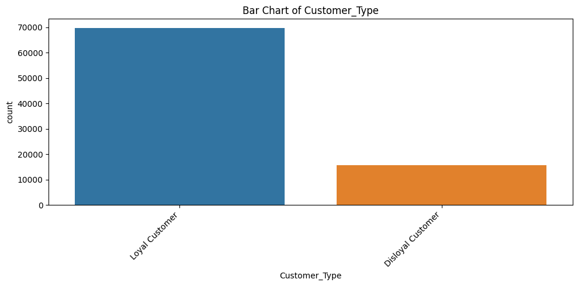

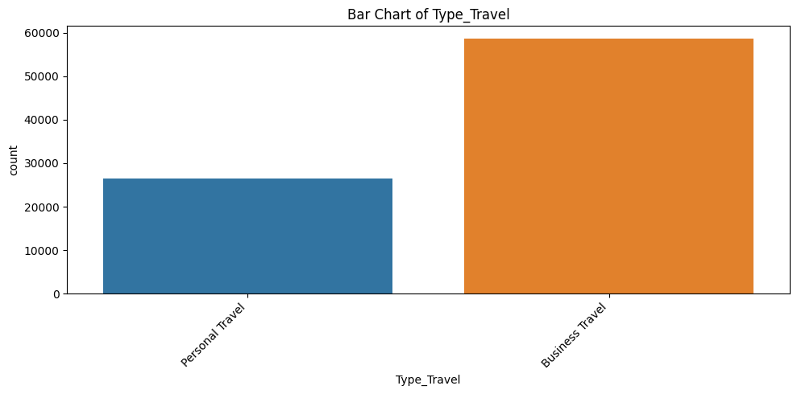

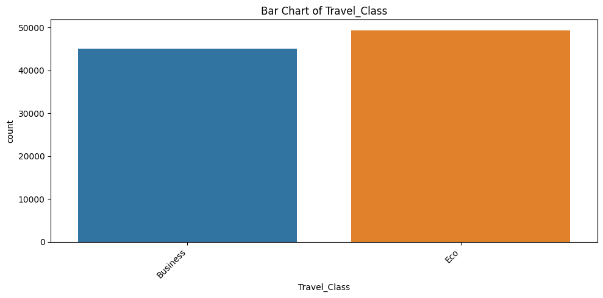

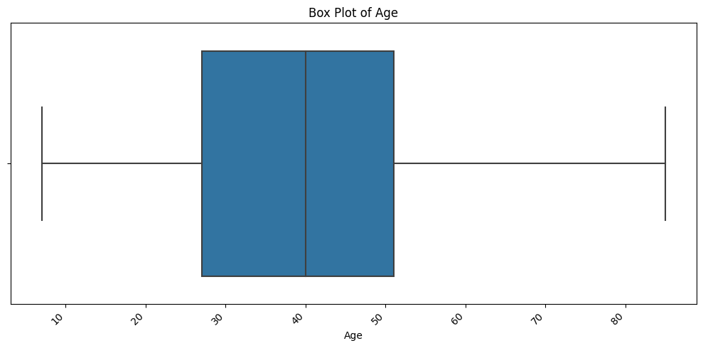

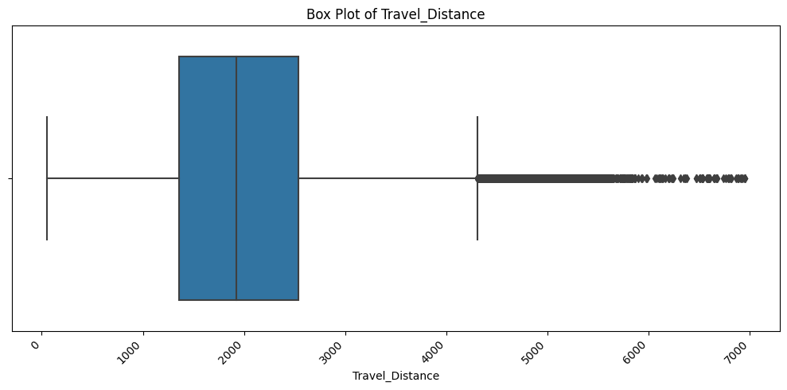

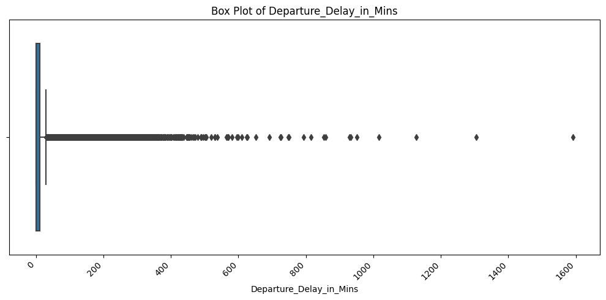

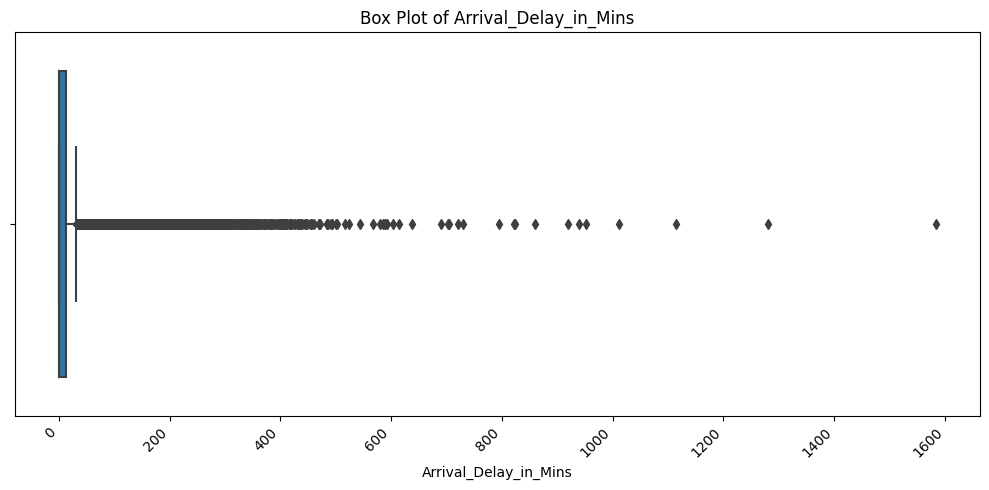

```python
# Let's see what distributions we have here to determine if there are any variables that are not helpful

# Filter out the "ID" column from the DataFrame
object_columns = ['Gender', 'Customer_Type', 'Type_Travel', 'Travel_Class']
numerical_columns = ['Age', 'Travel_Distance', 'Departure_Delay_in_Mins', 'Arrival_Delay_in_Mins']

# Create bar charts for object columns
for column in object_columns:
    plt.figure(figsize=(10, 5))
    sns.countplot(x=column, data=travel_data_train)
    plt.title(f'Bar Chart of {column}')
    plt.xticks(rotation=45, ha='right')
    plt.tight_layout()  # Adjust the layout to ensure labels are not cut off
    plt.show()

# Create box plots for numerical columns
for column in numerical_columns:
    plt.figure(figsize=(10, 5))
    sns.boxplot(x=column, data=travel_data_train)
    plt.title(f'Box Plot of {column}')
    plt.xticks(rotation=45, ha='right')
    plt.tight_layout()  # Adjust the layout to ensure labels are not cut off
    plt.show()
```

We'll have to treat the outlier variables carefully, and both put them on a log scale and then scale them further.

## Exploring travel_data_test

```python
travel_data_test.info()
```

```
<class 'pandas.core.frame.DataFrame'>
RangeIndex: 35602 entries, 0 to 35601
Data columns (total 9 columns):
 #   Column                   Non-Null Count  Dtype
---  ------                   --------------  -----
 0   ID                       35602 non-null  int64
 1   Gender                   35572 non-null  object
 2   Customer_Type            32219 non-null  object
 3   Age                      35591 non-null  float64
 4   Type_Travel              32154 non-null  object
 5   Travel_Class             35602 non-null  object
 6   Travel_Distance          35602 non-null  int64
 7   Departure_Delay_in_Mins  35573 non-null  float64
 8   Arrival_Delay_in_Mins    35479 non-null  float64
dtypes: float64(3), int64(2), object(4)
memory usage: 2.4+ MB
```

```python
travel_data_test.describe().T
```

|  | count | mean | std | min | 25% | 50% | 75% | max |
| --- | --- | --- | --- | --- | --- | --- | --- | --- |
| ID | 35602.0 | 9.991780e+07 | 10277.556478 | 99900001.0 | 99908901.25 | 99917801.5 | 99926701.75 | 99935602.0 |
| Age | 35591.0 | 3.944700e+01 | 15.137554 | 7.0 | 27.00 | 40.0 | 51.00 | 85.0 |
| Travel_Distance | 35602.0 | 1.987152e+03 | 1024.308863 | 50.0 | 1360.00 | 1929.0 | 2559.00 | 6868.0 |
| Departure_Delay_in_Mins | 35573.0 | 1.488070e+01 | 37.895453 | 0.0 | 0.00 | 0.0 | 13.00 | 978.0 |
| Arrival_Delay_in_Mins | 35479.0 | 1.530880e+01 | 38.531293 | 0.0 | 0.00 | 0.0 | 13.00 | 970.0 |

```python
travel_data_test.describe(include=[object]).T
```

|  | count | unique | top | freq |
| --- | --- | --- | --- | --- |
| Gender | 35572 | 2 | Female | 18069 |
| Customer_Type | 32219 | 2 | Loyal Customer | 26349 |
| Type_Travel | 32154 | 2 | Business Travel | 22313 |
| Travel_Class | 35602 | 2 | Eco | 18473 |

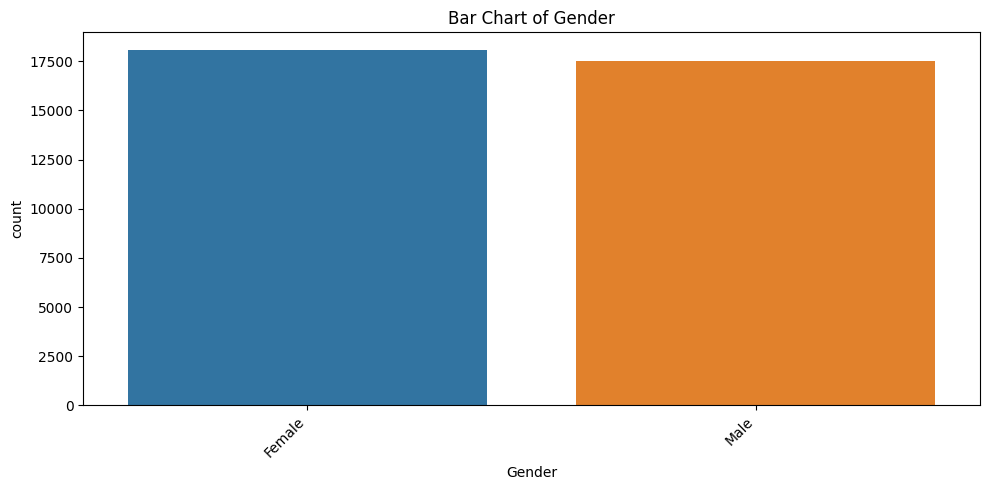

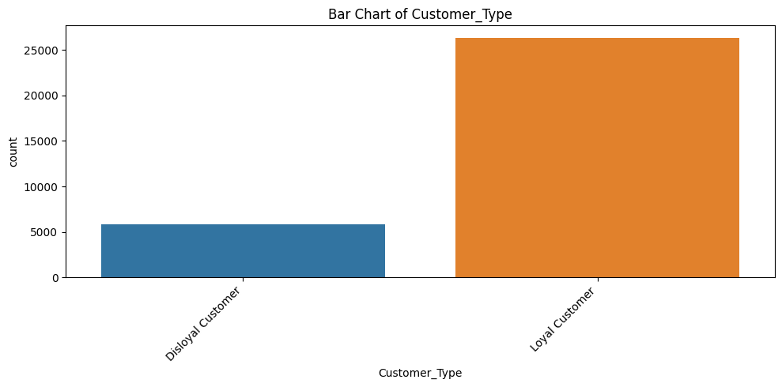

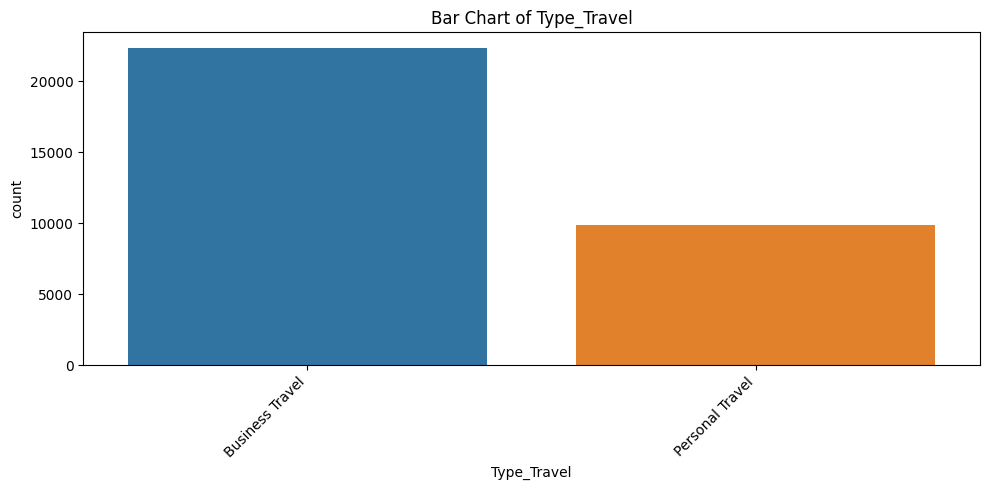

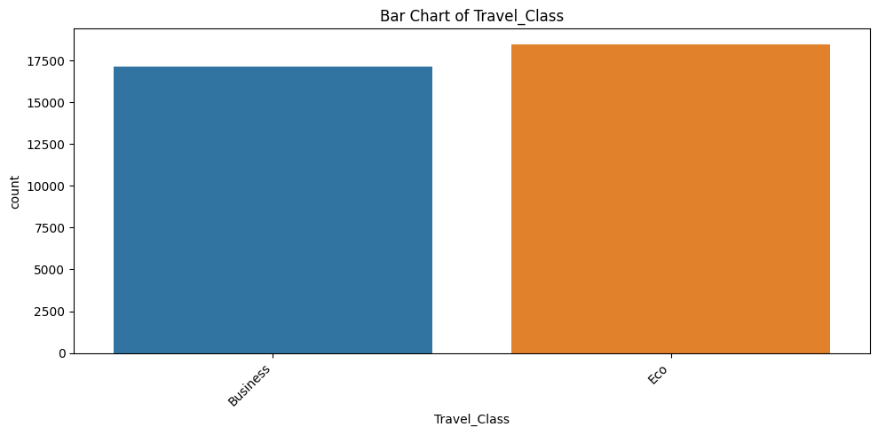

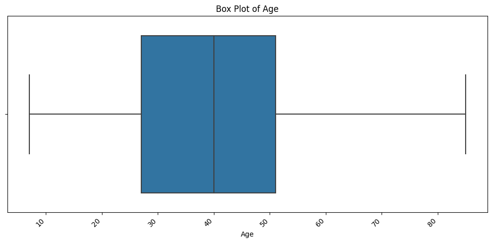

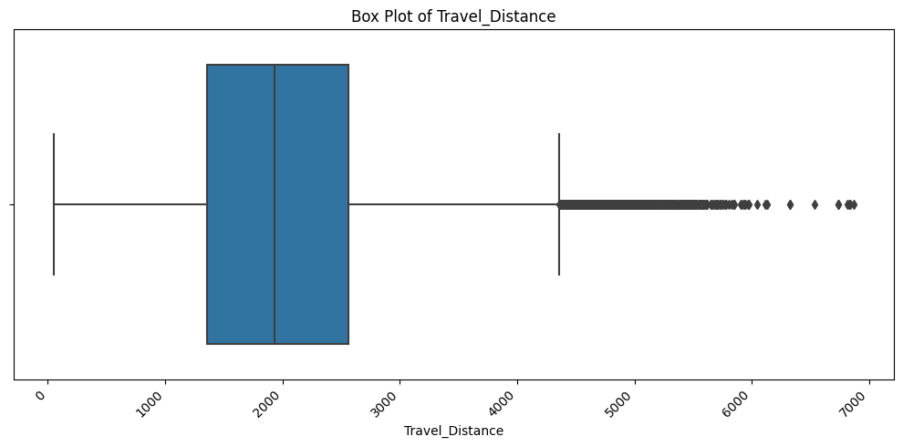

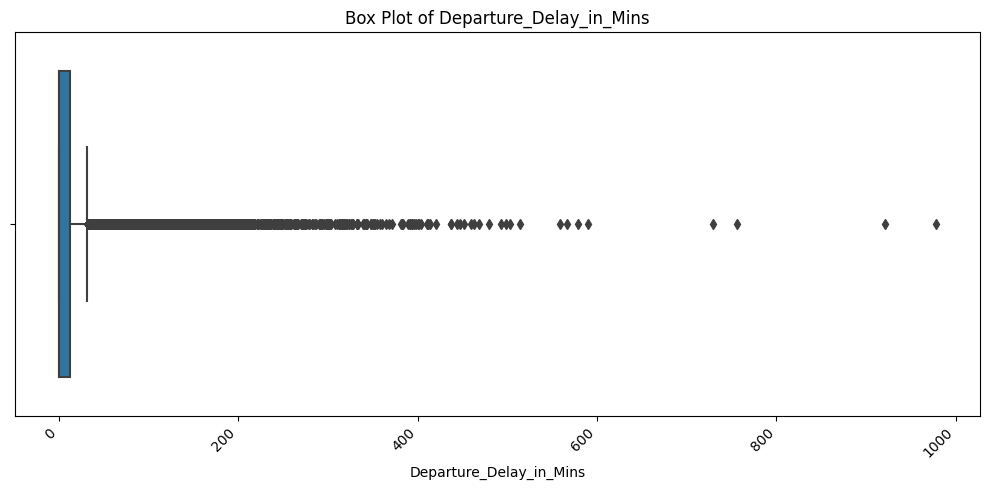

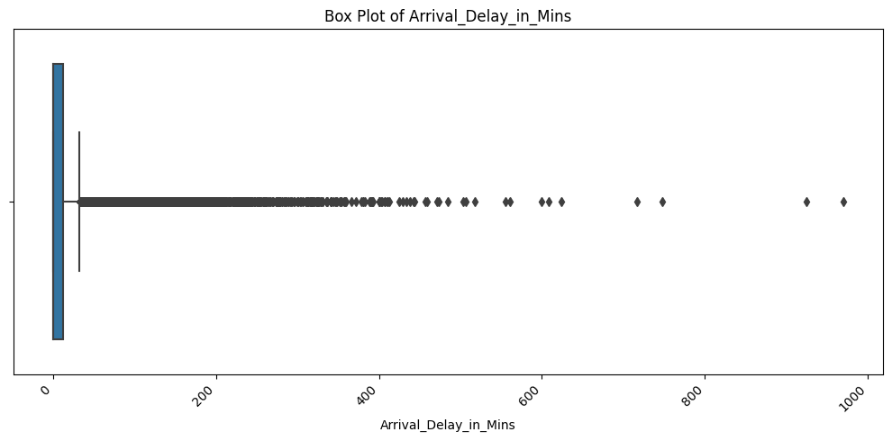

```python
# Filter out the "ID" column from the DataFrame
object_columns = ['Gender', 'Customer_Type', 'Type_Travel', 'Travel_Class']
numerical_columns = ['Age', 'Travel_Distance', 'Departure_Delay_in_Mins', 'Arrival_Delay_in_Mins']

# Create bar charts for object columns
for column in object_columns:
    plt.figure(figsize=(10, 5))
    sns.countplot(x=column, data=travel_data_test)
    plt.title(f'Bar Chart of {column}')
    plt.xticks(rotation=45, ha='right')
    plt.tight_layout()  # Adjust the layout to ensure labels are not cut off
    plt.show()

# Create box plots for numerical columns
for column in numerical_columns:
    plt.figure(figsize=(10, 5))
    sns.boxplot(x=column, data=travel_data_test)
    plt.title(f'Box Plot of {column}')
    plt.xticks(rotation=45, ha='right')
    plt.tight_layout()  # Adjust the layout to ensure labels are not cut off
    plt.show()
```

The distributions between travel_data_train and travel_data_test appear to be very similar, which is a good sign that they've been sampled appropriately.

After examining the travel_data_test dataset, it looks the labels, datatypes, and distributions are quite similar to the travel_data_train dataset, with the exception that it looks like there are fewer missing values in this set. I can make all the same changes that I made to the other dataset, except I will not drop the ID column as I need that for the final prediction.

```python
# Checking for bad data and non-numerical characters in the numerical columns

# Assigning columns
columns_to_check = travel_data_test.select_dtypes(include=['float64', 'int64']).columns

# Regular expression for non-numerical characters
regex_pattern = '[^\d.-]'

for column in columns_to_check:
    # Find rows with non-numerical data ignoring NaN values
    non_numerical_rows = travel_data_test[column].dropna().astype(str).str.contains(regex_pattern, regex=True)

    # Get indices of these rows
    non_numerical_indices = non_numerical_rows[non_numerical_rows].index

    if not non_numerical_indices.empty:
        print(f"Column '{column}' has {len(non_numerical_indices)} rows with non-numerical data.")
        print(f"Indices of these rows: {list(non_numerical_indices)}")

    else:
        print(f"No non-numerical data found in '{column}'.")
```

```
No non-numerical data found in 'ID'.
No non-numerical data found in 'Age'.
No non-numerical data found in 'Travel_Distance'.
No non-numerical data found in 'Departure_Delay_in_Mins'.
No non-numerical data found in 'Arrival_Delay_in_Mins'.
```

No non-numerical data or duplicate data was found in either of the travel_data datasets, so I will proceed with applying the outlined steps for handling null values and other changes to the columns.

### Cleaning the travel data sets

I start by reloading to decrease the number of cells that I have to run when restarting or developing another model.

```python
# Reload the dataset
travel_data_train = pd.read_csv(travel_data_train_path)

# Make a copy of the dataset
df_travel_train = travel_data_train.copy()

# Impute missing values for 'Gender' with mode
gender_mode = df_travel_train['Gender'].mode()[0]
df_travel_train['Gender'].fillna(gender_mode, inplace=True)

# Create 'Unknown' category for missing values in 'Customer_Type' and 'Type_Travel'
for column in ['Customer_Type', 'Type_Travel']:
    df_travel_train[column].fillna('Unknown', inplace=True)

# Impute missing values for 'Age' with median
age_median = df_travel_train['Age'].median()
df_travel_train['Age'].fillna(age_median, inplace=True)

# Convert 'Gender', 'Customer_Type', 'Type_Travel', and 'Travel_Class' to 'category'
for column in ['Gender', 'Customer_Type', 'Type_Travel', 'Travel_Class']:
    df_travel_train[column] = df_travel_train[column].astype('category')

# Impute missing values for 'Departure_Delay_in_Mins' and 'Arrival_Delay_in_Mins' with median
for column in ['Departure_Delay_in_Mins', 'Arrival_Delay_in_Mins']:
    median_value = df_travel_train[column].median()
    df_travel_train[column].fillna(median_value, inplace=True)

# Apply logarithmic transformation to 'Departure_Delay_in_Mins' and 'Arrival_Delay_in_Mins'
for column in ['Departure_Delay_in_Mins', 'Arrival_Delay_in_Mins']:
    df_travel_train[column] = np.log1p(df_travel_train[column])

# One-hot encoding for categorical variables, dropping the first column
df_travel_train = pd.get_dummies(df_travel_train, columns=['Gender', 'Customer_Type', 'Type_Travel', 'Travel_Class'], drop_first=True)

df_travel_train.head()
```

|  | ID | Age | Travel_Distance | Departure_Delay_in_Mins | Arrival_Delay_in_Mins | Gender_Male | Customer_Type_Loyal Customer | Customer_Type_Unknown | Type_Travel_Personal Travel | Type_Travel_Unknown | Travel_Class_Eco |
| --- | --- | --- | --- | --- | --- | --- | --- | --- | --- | --- | --- |
| 0 | 98800001 | 52.0 | 272 | 0.000000 | 1.791759 | 0 | 1 | 0 | 0 | 1 | 0 |
| 1 | 98800002 | 48.0 | 2200 | 2.302585 | 0.000000 | 1 | 1 | 0 | 1 | 0 | 1 |
| 2 | 98800003 | 43.0 | 1061 | 4.356709 | 4.787492 | 0 | 1 | 0 | 0 | 0 | 0 |
| 3 | 98800004 | 44.0 | 780 | 2.639057 | 2.944439 | 0 | 1 | 0 | 0 | 0 | 0 |
| 4 | 98800005 | 50.0 | 1981 | 0.000000 | 0.000000 | 0 | 1 | 0 | 0 | 0 | 0 |

```python
# Making the same changes to the travel_data_test set

# Reload the dataset
travel_data_test = pd.read_csv(travel_data_test_path)

# Make a copy of the dataset
df_travel_test = travel_data_test.copy()

# Impute missing values for 'Gender' with mode
gender_mode = df_travel_test['Gender'].mode()[0]
df_travel_test['Gender'].fillna(gender_mode, inplace=True)

# Create 'Unknown' category for missing values in 'Customer_Type' and 'Type_Travel'
for column in ['Customer_Type', 'Type_Travel']:
    df_travel_test[column].fillna('Unknown', inplace=True)

# Impute missing values for 'Age' with median
age_median = df_travel_test['Age'].median()
df_travel_test['Age'].fillna(age_median, inplace=True)

# Convert 'Gender', 'Customer_Type', 'Type_Travel', and 'Travel_Class' to 'category'
for column in ['Gender', 'Customer_Type', 'Type_Travel', 'Travel_Class']:
    df_travel_test[column] = df_travel_test[column].astype('category')

# Impute missing values for 'Departure_Delay_in_Mins' and 'Arrival_Delay_in_Mins' with median
for column in ['Departure_Delay_in_Mins', 'Arrival_Delay_in_Mins']:
    median_value = df_travel_test[column].median()
    df_travel_test[column].fillna(median_value, inplace=True)

# Apply logarithmic transformation to 'Departure_Delay_in_Mins' and 'Arrival_Delay_in_Mins'
for column in ['Departure_Delay_in_Mins', 'Arrival_Delay_in_Mins']:
    df_travel_test[column] = np.log1p(df_travel_test[column])

# One-hot encoding for categorical variables, dropping the first column
df_travel_test = pd.get_dummies(df_travel_test, columns=['Gender', 'Customer_Type', 'Type_Travel', 'Travel_Class'], drop_first=True)

df_travel_test.head()
```

|  | ID | Age | Travel_Distance | Departure_Delay_in_Mins | Arrival_Delay_in_Mins | Gender_Male | Customer_Type_Loyal Customer | Customer_Type_Unknown | Type_Travel_Personal Travel | Type_Travel_Unknown | Travel_Class_Eco |
| --- | --- | --- | --- | --- | --- | --- | --- | --- | --- | --- | --- |
| 0 | 99900001 | 36.0 | 532 | 0.000000 | 0.000000 | 0 | 0 | 1 | 0 | 0 | 0 |
| 1 | 99900002 | 21.0 | 1425 | 2.302585 | 3.367296 | 0 | 0 | 0 | 0 | 0 | 0 |
| 2 | 99900003 | 60.0 | 2832 | 0.000000 | 0.000000 | 1 | 1 | 0 | 0 | 0 | 0 |
| 3 | 99900004 | 29.0 | 1352 | 0.000000 | 0.000000 | 0 | 1 | 0 | 1 | 0 | 1 |
| 4 | 99900005 | 18.0 | 1610 | 2.890372 | 0.000000 | 1 | 0 | 0 | 0 | 0 | 0 |

Now I have the new datasets with these transformations applied. I dropped columns because my first model will use logistic regression and I want to avoid multi-collinearity. I will make one other feature engineering change of combining the departure delay and arrival delay data (using the original, non-logarithmic data) to express the Total_Delay. I will also scale all three of the Delay-related columns.

```python
from sklearn.preprocessing import StandardScaler

# Calculate Total_Delay
df_travel_train['Total_Delay_Log'] = np.log1p(travel_data_train['Departure_Delay_in_Mins'] + travel_data_train['Arrival_Delay_in_Mins'])
df_travel_test['Total_Delay_Log'] = np.log1p(travel_data_test['Departure_Delay_in_Mins'] + travel_data_test['Arrival_Delay_in_Mins'])

# Rename columns
df_travel_train.rename(columns={'Departure_Delay_in_Mins': 'Departure_Delay_Log',
                                'Arrival_Delay_in_Mins': 'Arrival_Delay_Log'}, inplace=True)
df_travel_test.rename(columns={'Departure_Delay_in_Mins': 'Departure_Delay_Log',
                               'Arrival_Delay_in_Mins': 'Arrival_Delay_Log'}, inplace=True)

# For now, I'm going to delay scaling until Logistic Regression,
# because I want it unscaled for the Decision Tree Model

# Initialize the scaler
# scaler = StandardScaler()

# Columns to scale
# delay_columns = ['Departure_Delay_Log', 'Arrival_Delay_Log', 'Total_Delay_Log', 'Travel_Distance']

# Apply scaling to the delay-related columns
#df_travel_train[delay_columns] = scaler.fit_transform(df_travel_train[delay_columns])
# df_travel_test[delay_columns] = scaler.transform(df_travel_test[delay_columns])

df_travel_train.head()
```

|  | ID | Age | Travel_Distance | Departure_Delay_Log | Arrival_Delay_Log | Gender_Male | Customer_Type_Loyal Customer | Customer_Type_Unknown | Type_Travel_Personal Travel | Type_Travel_Unknown | Travel_Class_Eco | Total_Delay_Log |
| --- | --- | --- | --- | --- | --- | --- | --- | --- | --- | --- | --- | --- |
| 0 | 98800001 | 52.0 | 272 | 0.000000 | 1.791759 | 0 | 1 | 0 | 0 | 1 | 0 | 1.791759 |
| 1 | 98800002 | 48.0 | 2200 | 2.302585 | 0.000000 | 1 | 1 | 0 | 1 | 0 | 1 | 2.302585 |
| 2 | 98800003 | 43.0 | 1061 | 4.356709 | 4.787492 | 0 | 1 | 0 | 0 | 0 | 0 | 5.283204 |
| 3 | 98800004 | 44.0 | 780 | 2.639057 | 2.944439 | 0 | 1 | 0 | 0 | 0 | 0 | 3.465736 |
| 4 | 98800005 | 50.0 | 1981 | 0.000000 | 0.000000 | 0 | 1 | 0 | 0 | 0 | 0 | 0.000000 |

I will consider other feature engineering options later. For now, let's proceed to examine the survey data.

## Exploring survey_data_train

```python
survey_data_train.head()
```

|  | ID | Overall_Experience | Seat_Comfort | Seat_Class | Arrival_Time_Convenient | Catering | Platform_Location | Onboard_Wifi_Service | Onboard_Entertainment | Online_Support | Ease_of_Online_Booking | Onboard_Service | Legroom | Baggage_Handling | CheckIn_Service | Cleanliness | Online_Boarding |
| --- | --- | --- | --- | --- | --- | --- | --- | --- | --- | --- | --- | --- | --- | --- | --- | --- | --- |
| 0 | 98800001 | 0 | Needs Improvement | Green Car | Excellent | Excellent | Very Convenient | Good | Needs Improvement | Acceptable | Needs Improvement | Needs Improvement | Acceptable | Needs Improvement | Good | Needs Improvement | Poor |
| 1 | 98800002 | 0 | Poor | Ordinary | Excellent | Poor | Needs Improvement | Good | Poor | Good | Good | Excellent | Needs Improvement | Poor | Needs Improvement | Good | Good |
| 2 | 98800003 | 1 | Needs Improvement | Green Car | Needs Improvement | Needs Improvement | Needs Improvement | Needs Improvement | Good | Excellent | Excellent | Excellent | Excellent | Excellent | Good | Excellent | Excellent |
| 3 | 98800004 | 0 | Acceptable | Ordinary | Needs Improvement | NaN | Needs Improvement | Acceptable | Needs Improvement | Acceptable | Acceptable | Acceptable | Acceptable | Acceptable | Good | Acceptable | Acceptable |
| 4 | 98800005 | 1 | Acceptable | Ordinary | Acceptable | Acceptable | Manageable | Needs Improvement | Good | Excellent | Good | Good | Good | Good | Good | Good | Good |

```python
survey_data_train.info()
```

```
<class 'pandas.core.frame.DataFrame'>
RangeIndex: 94379 entries, 0 to 94378
Data columns (total 17 columns):
 #   Column                   Non-Null Count  Dtype
---  ------                   --------------  -----
 0   ID                       94379 non-null  int64
 1   Overall_Experience       94379 non-null  int64
 2   Seat_Comfort             94318 non-null  object
 3   Seat_Class               94379 non-null  object
 4   Arrival_Time_Convenient  85449 non-null  object
 5   Catering                 85638 non-null  object
 6   Platform_Location        94349 non-null  object
 7   Onboard_Wifi_Service     94349 non-null  object
 8   Onboard_Entertainment    94361 non-null  object
 9   Online_Support           94288 non-null  object
 10  Ease_of_Online_Booking   94306 non-null  object
 11  Onboard_Service          86778 non-null  object
 12  Legroom                  94289 non-null  object
 13  Baggage_Handling         94237 non-null  object
 14  CheckIn_Service          94302 non-null  object
 15  Cleanliness              94373 non-null  object
 16  Online_Boarding          94373 non-null  object
dtypes: int64(2), object(15)
memory usage: 12.2+ MB
```

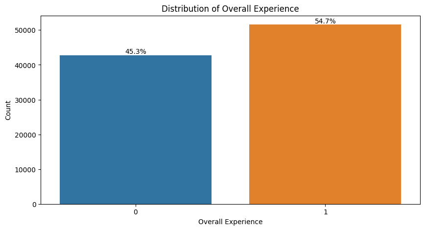

```python
# Plotting the distribution of Overall_Experience
plt.figure(figsize=(10, 5))
sns.countplot(x='Overall_Experience', data=survey_data_train)
plt.title('Distribution of Overall Experience')
plt.xlabel('Overall Experience')
plt.ylabel('Count')

# Showing percentages
# Add annotations with percentages
total_count = len(survey_data_train)
ax = plt.gca()
for p in ax.patches:
    height = p.get_height()
    ax.annotate(f'{height / total_count:.1%}', (p.get_x() + p.get_width() / 2., height),
                ha='center', va='bottom')

plt.show()
```

Interestingly, the dependent variable of interest, "Overall Experience", is pretty evenly split, with only 54.7% of riders rating their overall experience as "Satisfied".

```python
survey_data_train.describe(include=object).T
```

|  | count | unique | top | freq |
| --- | --- | --- | --- | --- |
| Seat_Comfort | 94318 | 6 | Acceptable | 21158 |
| Seat_Class | 94379 | 2 | Green Car | 47435 |
| Arrival_Time_Convenient | 85449 | 6 | Good | 19574 |
| Catering | 85638 | 6 | Acceptable | 18468 |
| Platform_Location | 94349 | 6 | Manageable | 24173 |
| Onboard_Wifi_Service | 94349 | 6 | Good | 22835 |
| Onboard_Entertainment | 94361 | 6 | Good | 30446 |
| Online_Support | 94288 | 6 | Good | 30016 |
| Ease_of_Online_Booking | 94306 | 6 | Good | 28909 |
| Onboard_Service | 86778 | 6 | Good | 27265 |
| Legroom | 94289 | 6 | Good | 28870 |
| Baggage_Handling | 94237 | 5 | Good | 34944 |
| CheckIn_Service | 94302 | 6 | Good | 26502 |
| Cleanliness | 94373 | 6 | Good | 35427 |
| Online_Boarding | 94373 | 6 | Good | 25533 |

```python
null_percentage = round(survey_data_train.isnull().mean() * 100, 1)
print(null_percentage)
```

```
ID                         0.0
Overall_Experience         0.0
Seat_Comfort               0.1
Seat_Class                 0.0
Arrival_Time_Convenient    9.5
Catering                   9.3
Platform_Location          0.0
Onboard_Wifi_Service       0.0
Onboard_Entertainment      0.0
Online_Support             0.1
Ease_of_Online_Booking     0.1
Onboard_Service            8.1
Legroom                    0.1
Baggage_Handling           0.2
CheckIn_Service            0.1
Cleanliness                0.0
Online_Boarding            0.0
dtype: float64
```

We've previously determined that there are no duplicate values in this dataset. Obviously, there are missing values in some columns, with some of them representing a very small percentage (0.1-0.2%) and three columns with larger percentages missing (8.1-9.5%). These are Arrival_Time_Convenient, Catering, and Onboard_Service. The missing values in Catering and Onboard_Service might be due to riders not using those services during the trip, but it's not clear why a rider would not have selected an answer for Arrival_Time_Convenient.

Initially, I will plan to convert all of these from the 'object' to the 'category' datatype, impute the most common value for the missing values in the columns missing 0.1% or 0.2% of observations, and create a new option, "Unknown" for the columns with 8-9% missing values, since this missingness might be important.

I will also need to apply Label Encoding to all the categorical variables.

Before I do that, I will examine the distributions of these columns to determine if I can remove any of them from consideration, and then examine survey_data_test to determine that these changes still make sense for that data set.

```python
# Checking for bad data and non-numerical characters in the numerical columns

# Assuming travel_data_test is your DataFrame
columns_to_check = survey_data_train.select_dtypes(include=['float64', 'int64']).columns

# Regular expression for non-numerical characters
regex_pattern = '[^\d.-]'

for column in columns_to_check:
    # Find rows with non-numerical data ignoring NaN values
    non_numerical_rows = survey_data_train[column].dropna().astype(str).str.contains(regex_pattern, regex=True)

    # Get indices of these rows
    non_numerical_indices = non_numerical_rows[non_numerical_rows].index

    if not non_numerical_indices.empty:
        print(f"Column '{column}' has {len(non_numerical_indices)} rows with non-numerical data.")
        print(f"Indices of these rows: {list(non_numerical_indices)}")

    else:
        print(f"No non-numerical data found in '{column}'.")
```

```
No non-numerical data found in 'ID'.
No non-numerical data found in 'Overall_Experience'.
```

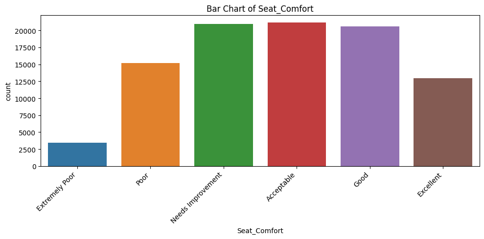

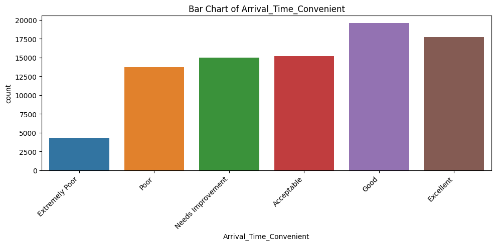

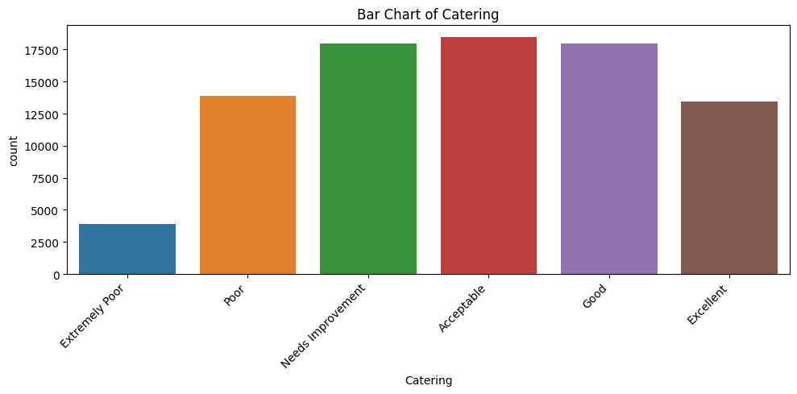

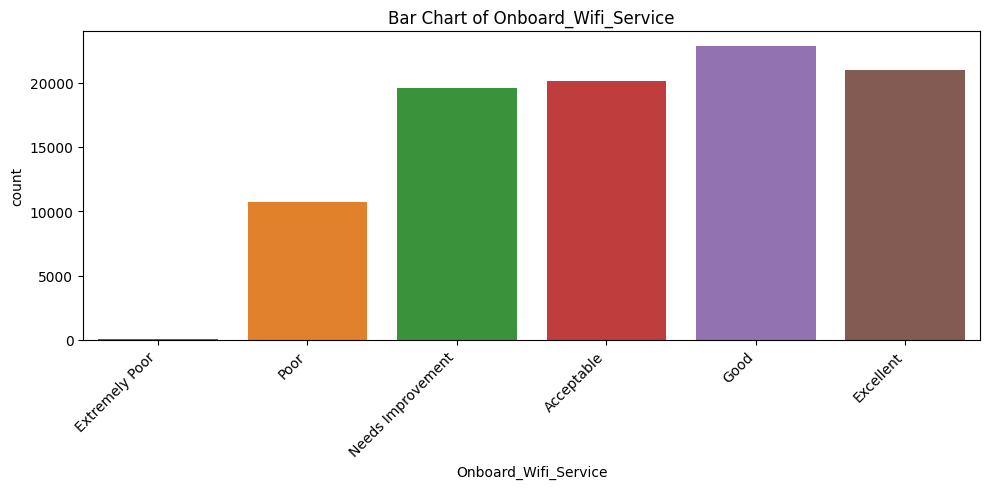

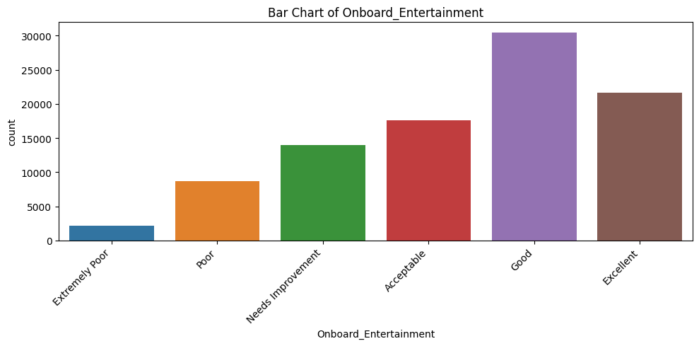

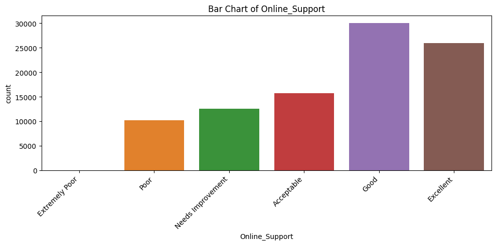

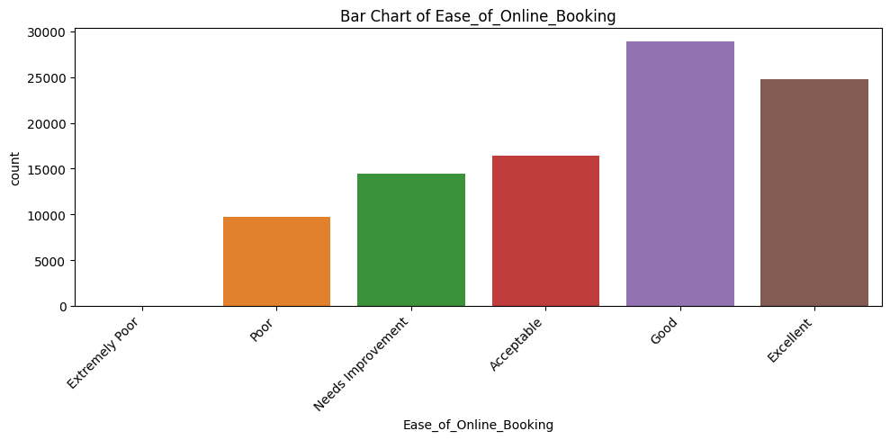

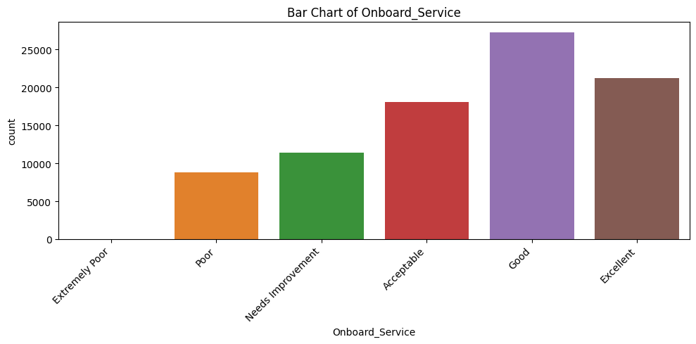

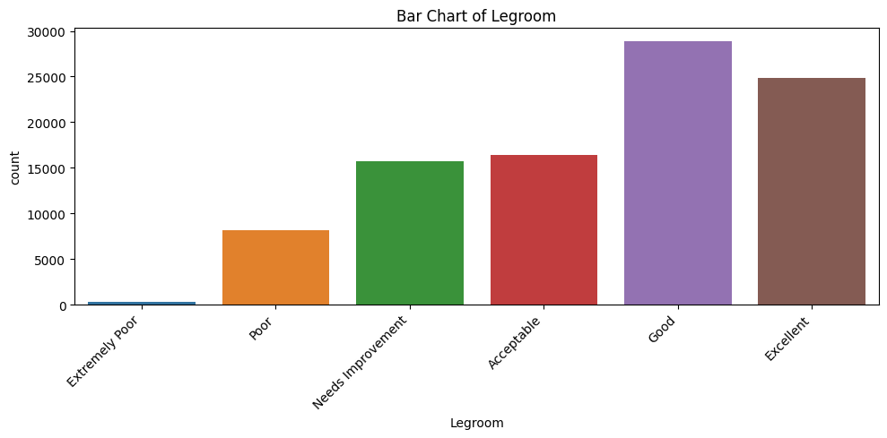

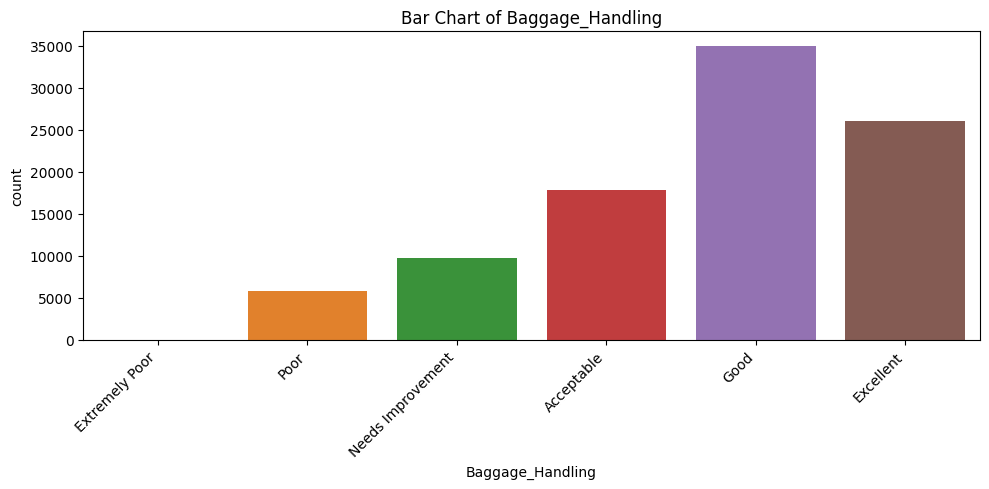

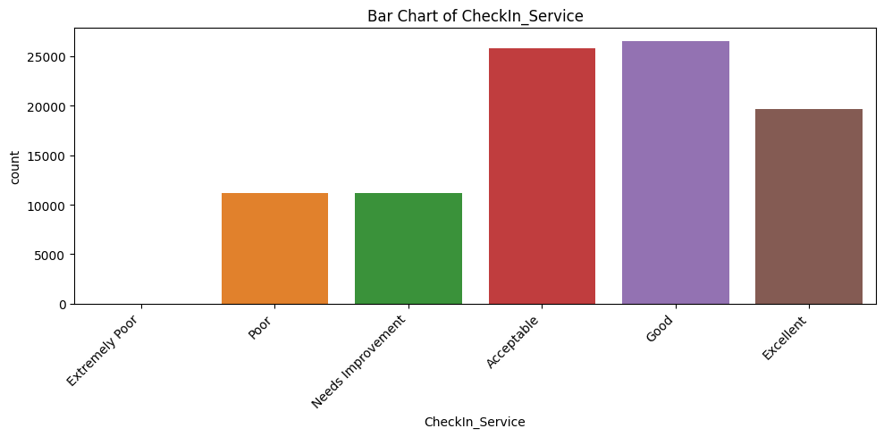

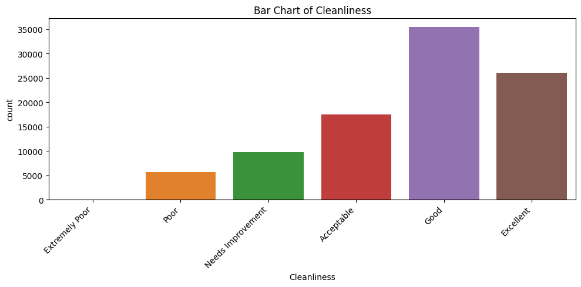

[1 more figures not shown]

```python
# Creating charts for each of the categorical variables

# List of columns for which to create bar charts
columns_to_plot = [
    'Seat_Comfort', 'Arrival_Time_Convenient', 'Catering', 'Onboard_Wifi_Service',
    'Onboard_Entertainment', 'Online_Support', 'Ease_of_Online_Booking', 'Onboard_Service',
    'Legroom', 'Baggage_Handling', 'CheckIn_Service', 'Cleanliness', 'Online_Boarding'
]

# Define the desired order for all columns
category_orders = {
    column: ['Extremely Poor', 'Poor', 'Needs Improvement', 'Acceptable', 'Good', 'Excellent']
    for column in columns_to_plot
}

# Block of code that creates a bar chart for each categorical column with the specified order
for column in columns_to_plot:
    plt.figure(figsize=(10, 5))
    sns.countplot(x=column, data=survey_data_train, order=category_orders[column])
    plt.title(f'Bar Chart of {column}')
    plt.xticks(rotation=45, ha='right')
    plt.tight_layout()  # Adjust the layout to ensure labels are not cut off
    plt.show()
```

Interestingly, the distributions for each of the categorical variables are not wildly different, with the biggest differences between charts being the number of "Extremely Poor" and "Good" ratings, with some categories having a relatively large number of "Extremely Poor" ratings and many having none, while the "Good" ratings vary significantly among some of the columns.

Fortunately, this means that all of these variables appear to provide valuable information. Unfortunately, this means I don't have any variables I can drop from the analysis. After I apply label encoding, there will be a very large number of dimensions, which will complicate analysis.

## Exploring survey_data_test

```python
survey_data_test.head()
```

|  | ID | Seat_Comfort | Seat_Class | Arrival_Time_Convenient | Catering | Platform_Location | Onboard_Wifi_Service | Onboard_Entertainment | Online_Support | Ease_of_Online_Booking | Onboard_Service | Legroom | Baggage_Handling | CheckIn_Service | Cleanliness | Online_Boarding |
| --- | --- | --- | --- | --- | --- | --- | --- | --- | --- | --- | --- | --- | --- | --- | --- | --- |
| 0 | 99900001 | Acceptable | Green Car | Acceptable | Acceptable | Manageable | Needs Improvement | Excellent | Good | Excellent | Excellent | Excellent | Excellent | Good | Excellent | Poor |
| 1 | 99900002 | Extremely Poor | Ordinary | Good | Poor | Manageable | Acceptable | Poor | Acceptable | Acceptable | Excellent | Acceptable | Good | Acceptable | Excellent | Acceptable |
| 2 | 99900003 | Excellent | Ordinary | Excellent | Excellent | Very Convenient | Excellent | Excellent | Excellent | Needs Improvement | Needs Improvement | Needs Improvement | Needs Improvement | Good | Needs Improvement | Excellent |
| 3 | 99900004 | Acceptable | Green Car | Excellent | Acceptable | Very Convenient | Poor | Acceptable | Excellent | Poor | Acceptable | Needs Improvement | Excellent | Excellent | Excellent | Poor |
| 4 | 99900005 | Excellent | Ordinary | Extremely Poor | Excellent | Needs Improvement | Excellent | Excellent | Excellent | Excellent | NaN | Acceptable | Excellent | Excellent | Excellent | Excellent |

```python
survey_data_test.info()
```

```
<class 'pandas.core.frame.DataFrame'>
RangeIndex: 35602 entries, 0 to 35601
Data columns (total 16 columns):
 #   Column                   Non-Null Count  Dtype
---  ------                   --------------  -----
 0   ID                       35602 non-null  int64
 1   Seat_Comfort             35580 non-null  object
 2   Seat_Class               35602 non-null  object
 3   Arrival_Time_Convenient  32277 non-null  object
 4   Catering                 32245 non-null  object
 5   Platform_Location        35590 non-null  object
 6   Onboard_Wifi_Service     35590 non-null  object
 7   Onboard_Entertainment    35594 non-null  object
 8   Online_Support           35576 non-null  object
 9   Ease_of_Online_Booking   35584 non-null  object
 10  Onboard_Service          32730 non-null  object
 11  Legroom                  35577 non-null  object
 12  Baggage_Handling         35562 non-null  object
 13  CheckIn_Service          35580 non-null  object
 14  Cleanliness              35600 non-null  object
 15  Online_Boarding          35600 non-null  object
dtypes: int64(1), object(15)
memory usage: 4.3+ MB
```

```python
null_percentage = round(survey_data_test.isnull().mean() * 100, 1)
print(null_percentage)
```

```
ID                         0.0
Seat_Comfort               0.1
Seat_Class                 0.0
Arrival_Time_Convenient    9.3
Catering                   9.4
Platform_Location          0.0
Onboard_Wifi_Service       0.0
Onboard_Entertainment      0.0
Online_Support             0.1
Ease_of_Online_Booking     0.1
Onboard_Service            8.1
Legroom                    0.1
Baggage_Handling           0.1
CheckIn_Service            0.1
Cleanliness                0.0
Online_Boarding            0.0
dtype: float64
```

```python
survey_data_test.describe(include=object).T
```

|  | count | unique | top | freq |
| --- | --- | --- | --- | --- |
| Seat_Comfort | 35580 | 6 | Acceptable | 8003 |
| Seat_Class | 35602 | 2 | Ordinary | 17860 |
| Arrival_Time_Convenient | 32277 | 6 | Good | 7361 |
| Catering | 32245 | 6 | Acceptable | 7133 |
| Platform_Location | 35590 | 5 | Manageable | 9364 |
| Onboard_Wifi_Service | 35590 | 6 | Good | 8743 |
| Onboard_Entertainment | 35594 | 6 | Good | 11436 |
| Online_Support | 35576 | 5 | Good | 11487 |
| Ease_of_Online_Booking | 35584 | 6 | Good | 11025 |
| Onboard_Service | 32730 | 5 | Good | 10222 |
| Legroom | 35577 | 6 | Good | 10842 |
| Baggage_Handling | 35562 | 5 | Good | 13291 |
| CheckIn_Service | 35580 | 5 | Good | 9982 |
| Cleanliness | 35600 | 5 | Good | 13421 |
| Online_Boarding | 35600 | 6 | Good | 9680 |